# Basics Stats

Mercedeh Movassagh PhD, Yale University

2023-07-22

## Overview of this R Markdown

This R Markdown document is prepared for teaching basic statistical sensitivity tests, simple regression models and ROC plots in R. The datasets used in this session are all part of the standard libraries used in the R markdown tutorial.

```r
library(ggpubr)
library(dplyr)
library(ggplot2)
library(tidyverse)
library(palmerpenguins)
library(ggstatsplot)
library(MASS)
library(ISLR2)
library(car)
library(caret)
library(pROC)
library(verification)
```

## T.test

```r
Ex_species<-iris
table(Ex_species$Species) #how many measurements are present for all the species variable
```

```
##
##     setosa versicolor  virginica
##         50         50         50
```

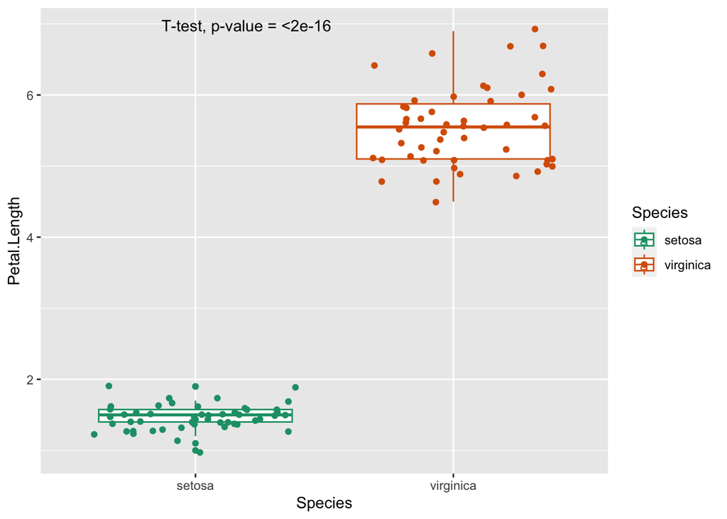

```r
Ex_species<-Ex_species%>%filter(!Species %in% c("versicolor"))
Ex_species$Species<-factor(Ex_species$Species)
# draw box plot and compare Petal.Length and Width between the setosa and virginica species
Spec<-Ex_species%>%dplyr::select(Petal.Length,Species)
SpecPlot<-ggplot(Spec, aes(x=Species, y=Petal.Length, color=Species)) +
 geom_boxplot() +
  geom_jitter() +
    labs(x = "Species", y = "Petal.Length", fill = "Species", color = "Species") +
    scale_color_brewer(palette="Dark2")
method <- "t.test" # one of "wilcox.test" or "t.test"
paired <- FALSE
print(SpecPlot + stat_compare_means(aes(label = paste0(after_stat(method), ", p-value = ", after_stat(p.format))),
      method = method,
      paired = paired,
      # group.by = NULL,
      ref.group = NULL
))
```

```r
print(t.test(Ex_species$Petal.Length ~ Ex_species$Species))#Print just the P test results
```

```
##
##  Welch Two Sample t-test
##
## data:  Ex_species$Petal.Length by Ex_species$Species
## t = -49.986, df = 58.609, p-value < 2.2e-16
## alternative hypothesis: true difference in means between group setosa and group virginica is not equal to 0
## 95 percent confidence interval:
##  -4.253749 -3.926251
## sample estimates:
##    mean in group setosa mean in group virginica
##                   1.462                   5.552
```

## ANOVA

As mentioned ANOVA is used when we want to compare groups. Basically, what we are testing is there is a difference between the groups we are comparing. In this new penguins data set we are trying to compare the length of flippers of various penguin species using ANOVA.Choosing ANOVA type is really related to the type of independent variable. If you have two independent variables you should use two way ANOVA if there is one you use one way ANOVA.

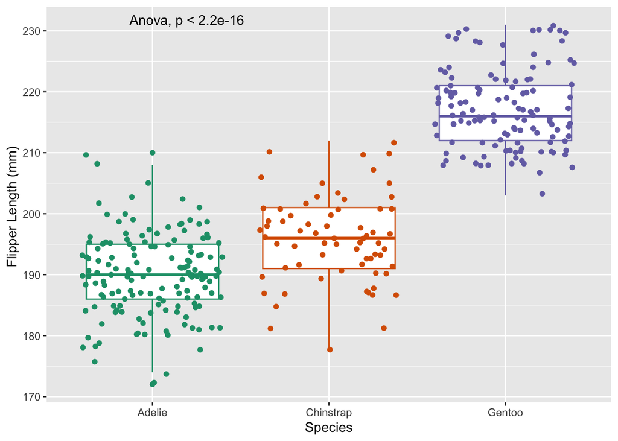

```r
Spec_Pangs<-penguins %>%
  dplyr::select(species, flipper_length_mm)
pang_plot<-ggplot(Spec_Pangs) +
  aes(x = species, y = flipper_length_mm, color = species) +
  geom_boxplot() +
  geom_jitter() +
    labs(x = "Species", y = "Flipper Length (mm) ", fill = "Species", color = "Species") +
    scale_color_brewer(palette="Dark2")+theme(legend.position = "none")
res_aov2 <- aov(flipper_length_mm ~ species,
  data = Spec_Pangs
)
print(pang_plot +  stat_compare_means(method = "anova"
))
```

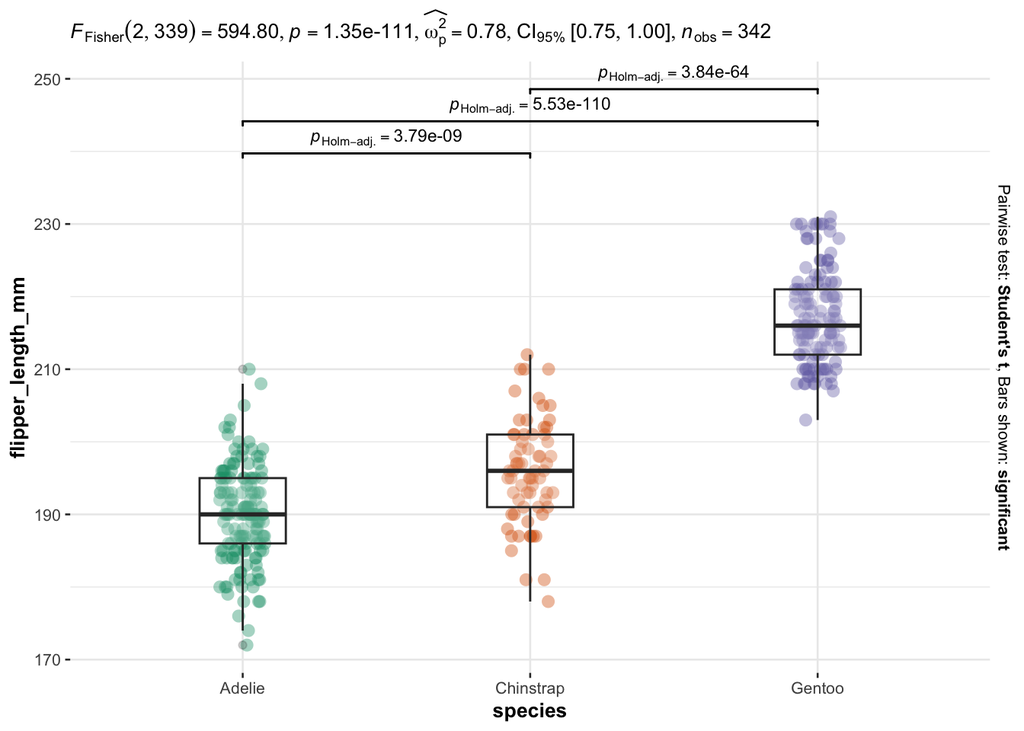

```r
#Method2
pang_plot2<-ggbetweenstats(
  data = Spec_Pangs,
  x = species,
  y = flipper_length_mm,
  type = "parametric", # ANOVA
  var.equal = TRUE, # ANOVA or Welch ANOVA
  plot.type = "box",
  pairwise.comparisons = TRUE,
  pairwise.display = "significant",
  centrality.plotting = FALSE,
  bf.message = FALSE,
  palette = "Dark2"
)
pang_plot2
```

## Fisher Test

Remember for Fisher Test you would need a smaller variable observation and it needs to be a categorical observation. Here, we are interested to see the difference in smokers and non-smokers developing long cancer.

```r
#Create your own contingency table
smoking_dt <- data.frame(
  "smoke_no" = c(9, 0),
  "smoke_yes" = c(2, 8),
  row.names = c("no-cancer", "cancer"),
  stringsAsFactors = FALSE
)
colnames(smoking_dt) <- c("Non-smoker", "Smoker")
smoking_dt
```

```
##           Non-smoker Smoker
## no-cancer          9      2
## cancer             0      8
```

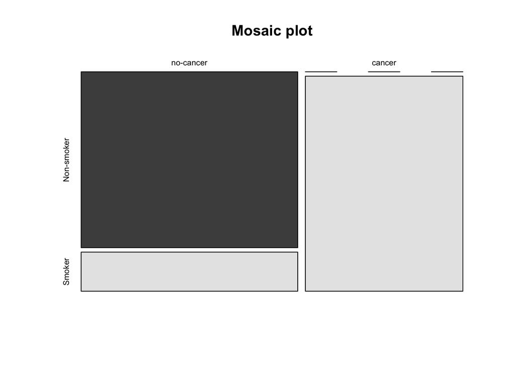

```r
#You can make a mosaic plot for visualizing the contingency table
mos_smoke<-mosaicplot(smoking_dt,
  main = "Mosaic plot",
  color = TRUE
)
```

```r
mos_smoke
```

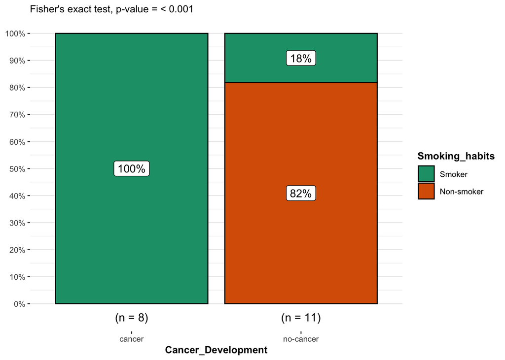

```r
#Make a dataset of that resonates the above contingency table.
x <- c()
for (row in rownames(smoking_dt)) {
  for (col in colnames(smoking_dt)) {
    x <- rbind(x, matrix(rep(c(row, col), smoking_dt[row, col]), ncol = 2, byrow = TRUE))
  }
}
smoking_dt2 <- as.data.frame(x)
colnames(smoking_dt2) <- c("Cancer_Development", "Smoking_habits")
f_test<-fisher.test(table(smoking_dt2))
#Create a bar plot with fisher test statistics on the difference between smoking habits and development of cancer.
ggbarstats(
  smoking_dt2, Smoking_habits, Cancer_Development,
  results.subtitle = FALSE,  palette = "Dark2",
  subtitle = paste0(
    "Fisher's exact test", ", p-value = ",
    ifelse(f_test$p.value < 0.001, "< 0.001", round(f_test$p.value, 3))
  )
)
```

## Chi-squared test

Recall, chi-squared test works by comparing the observed frequencies to the expected frequencies if there was no relationship between two categorical variables, in higher observed variable numbers recommended n>10. We go back to our initial penguins data set to show if there the species of the penguin is associated with the small or big category of the flipper length.

```r
Spec_Pangs_Chi<-Spec_Pangs
Spec_Pangs_Chi<-na.omit(Spec_Pangs_Chi)
Spec_Pangs_Chi$flipper_length <- ifelse(Spec_Pangs_Chi$flipper_length_mm < median(Spec_Pangs_Chi$flipper_length_mm),
  "small", "big"
)
#How does the contingency table look like?
table(Spec_Pangs_Chi$species, Spec_Pangs_Chi$flipper_length)
```

```
##
##             big small
##   Adelie     22   129
##   Chinstrap  31    37
##   Gentoo    123     0
```

```r
chisq.test(Spec_Pangs_Chi$flipper_length,Spec_Pangs_Chi$species)
```

```
##
##  Pearson's Chi-squared test
##
## data:  Spec_Pangs_Chi$flipper_length and Spec_Pangs_Chi$species
## X-squared = 199.23, df = 2, p-value < 2.2e-16
```

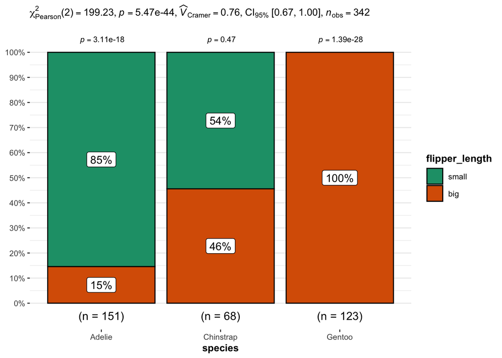

```r
#Draw a bar mosaic plot show statistics and chis-quare test for all observations:
ggbarstats(
  data = Spec_Pangs_Chi,
  x = flipper_length,
  y = species,
  palette = "Dark2"
) +
  labs(caption = NULL) # remove caption
```

## Linear Regression

We are now going to go over a linear expression example using the ISLR2. We want to predict median house value (medv) in Boston. We will use 12 predictors (features) to predict the medv (response).

```r
head(Boston)
```

```
##      crim zn indus chas   nox    rm  age    dis rad tax ptratio lstat medv
## 1 0.00632 18  2.31    0 0.538 6.575 65.2 4.0900   1 296    15.3  4.98 24.0
## 2 0.02731  0  7.07    0 0.469 6.421 78.9 4.9671   2 242    17.8  9.14 21.6
## 3 0.02729  0  7.07    0 0.469 7.185 61.1 4.9671   2 242    17.8  4.03 34.7
## 4 0.03237  0  2.18    0 0.458 6.998 45.8 6.0622   3 222    18.7  2.94 33.4
## 5 0.06905  0  2.18    0 0.458 7.147 54.2 6.0622   3 222    18.7  5.33 36.2
## 6 0.02985  0  2.18    0 0.458 6.430 58.7 6.0622   3 222    18.7  5.21 28.7
```

```r
#use lm() to run linear regression using age predictor
lm.fit<-lm(medv~age,data=Boston)
lm.fit
```

```
##
## Call:
## lm(formula = medv ~ age, data = Boston)
##
## Coefficients:
## (Intercept)          age
##     30.9787      -0.1232
```

```r
summary(lm.fit)
```

```
##
## Call:
## lm(formula = medv ~ age, data = Boston)
##
## Residuals:
##     Min      1Q  Median      3Q     Max
## -15.097  -5.138  -1.958   2.397  31.338
##
## Coefficients:
##             Estimate Std. Error t value Pr(>|t|)
## (Intercept) 30.97868    0.99911  31.006   <2e-16 ***
## age         -0.12316    0.01348  -9.137   <2e-16 ***
## ---
## Signif. codes:  0 '***' 0.001 '**' 0.01 '*' 0.05 '.' 0.1 ' ' 1
##
## Residual standard error: 8.527 on 504 degrees of freedom
## Multiple R-squared:  0.1421, Adjusted R-squared:  0.1404
## F-statistic: 83.48 on 1 and 504 DF,  p-value: < 2.2e-16
```

```r
#What are the stored variables in lm.fit
names(lm.fit)
```

```
##  [1] "coefficients"  "residuals"     "effects"       "rank"
##  [5] "fitted.values" "assign"        "qr"            "df.residual"
##  [9] "xlevels"       "call"          "terms"         "model"
```

```r
#What is the coefficient
coef(lm.fit)
```

```
## (Intercept)         age
##  30.9786778  -0.1231627
```

```r
#What is the 95% confidence interval?
confint(lm.fit)
```

```
##                  2.5 %      97.5 %
## (Intercept) 29.0157516 32.94160395
## age         -0.1496469 -0.09667852
```

```r
#Plot your fit
par(2,2)
```

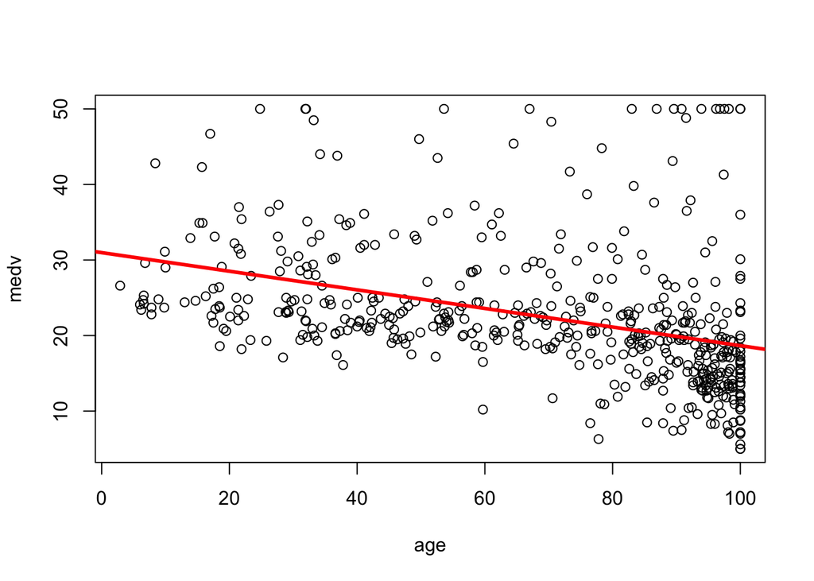

```r
attach(Boston)
plot(age,medv)
abline(lm.fit,col="red",lwd=3)
```

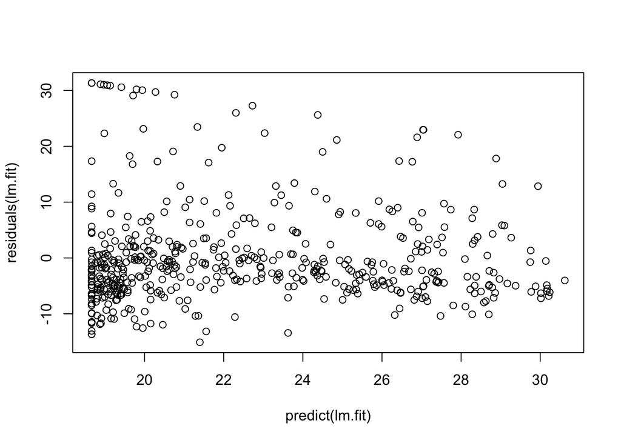

```r
#plot residual
plot(predict(lm.fit),residuals(lm.fit))
```

## Multiple Regression

In this section we want to see what happens if we have a more real situation when predicting median house value (medv) so we shall add more than 1 predictor to see the various predictor affects on the model.

```r
#Add percent of household with low socieoeconomic status (lstat)
multi_two_lm.fit<-lm(medv ~ age + lstat, data=Boston)
summary(multi_two_lm.fit)
```

```
##
## Call:
## lm(formula = medv ~ age + lstat, data = Boston)
##
## Residuals:
##     Min      1Q  Median      3Q     Max
## -15.981  -3.978  -1.283   1.968  23.158
##
## Coefficients:
##             Estimate Std. Error t value Pr(>|t|)
## (Intercept) 33.22276    0.73085  45.458  < 2e-16 ***
## age          0.03454    0.01223   2.826  0.00491 **
## lstat       -1.03207    0.04819 -21.416  < 2e-16 ***
## ---
## Signif. codes:  0 '***' 0.001 '**' 0.01 '*' 0.05 '.' 0.1 ' ' 1
##
## Residual standard error: 6.173 on 503 degrees of freedom
## Multiple R-squared:  0.5513, Adjusted R-squared:  0.5495
## F-statistic:   309 on 2 and 503 DF,  p-value: < 2.2e-16
```

```r
#Now add all other predictors:
lm.fit_all<-lm(medv ~ . , data=Boston)
summary(lm.fit_all)
```

```
##
## Call:
## lm(formula = medv ~ ., data = Boston)
##
## Residuals:
##      Min       1Q   Median       3Q      Max
## -15.1304  -2.7673  -0.5814   1.9414  26.2526
##
## Coefficients:
##               Estimate Std. Error t value Pr(>|t|)
## (Intercept)  41.617270   4.936039   8.431 3.79e-16 ***
## crim         -0.121389   0.033000  -3.678 0.000261 ***
## zn            0.046963   0.013879   3.384 0.000772 ***
## indus         0.013468   0.062145   0.217 0.828520
## chas          2.839993   0.870007   3.264 0.001173 **
## nox         -18.758022   3.851355  -4.870 1.50e-06 ***
## rm            3.658119   0.420246   8.705  < 2e-16 ***
## age           0.003611   0.013329   0.271 0.786595
## dis          -1.490754   0.201623  -7.394 6.17e-13 ***
## rad           0.289405   0.066908   4.325 1.84e-05 ***
## tax          -0.012682   0.003801  -3.337 0.000912 ***
## ptratio      -0.937533   0.132206  -7.091 4.63e-12 ***
## lstat        -0.552019   0.050659 -10.897  < 2e-16 ***
## ---
## Signif. codes:  0 '***' 0.001 '**' 0.01 '*' 0.05 '.' 0.1 ' ' 1
##
## Residual standard error: 4.798 on 493 degrees of freedom
## Multiple R-squared:  0.7343, Adjusted R-squared:  0.7278
## F-statistic: 113.5 on 12 and 493 DF,  p-value: < 2.2e-16
```

```r
#Get the rsquare value
summary(lm.fit_all)$r.sq
```

```
## [1] 0.734307
```

```r
#Get the RSE value
summary(lm.fit_all)$sigma
```

```
## [1] 4.798034
```

```r
#Compute variance inflation factor
vif(lm.fit_all)
```

```
##     crim       zn    indus     chas      nox       rm      age      dis
## 1.767486 2.298459 3.987181 1.071168 4.369093 1.912532 3.088232 3.954037
##      rad      tax  ptratio    lstat
## 7.445301 9.002158 1.797060 2.870777
```

```r
#If you want to see the affect a variable (remove a variable and compare with ANOVA before and after feature removal you can do the following)
lm.fit_all<-lm(medv ~ . , data=Boston)
summary(lm.fit_all)
```

```
##
## Call:
## lm(formula = medv ~ ., data = Boston)
##
## Residuals:
##      Min       1Q   Median       3Q      Max
## -15.1304  -2.7673  -0.5814   1.9414  26.2526
##
## Coefficients:
##               Estimate Std. Error t value Pr(>|t|)
## (Intercept)  41.617270   4.936039   8.431 3.79e-16 ***
## crim         -0.121389   0.033000  -3.678 0.000261 ***
## zn            0.046963   0.013879   3.384 0.000772 ***
## indus         0.013468   0.062145   0.217 0.828520
## chas          2.839993   0.870007   3.264 0.001173 **
## nox         -18.758022   3.851355  -4.870 1.50e-06 ***
## rm            3.658119   0.420246   8.705  < 2e-16 ***
## age           0.003611   0.013329   0.271 0.786595
## dis          -1.490754   0.201623  -7.394 6.17e-13 ***
## rad           0.289405   0.066908   4.325 1.84e-05 ***
## tax          -0.012682   0.003801  -3.337 0.000912 ***
## ptratio      -0.937533   0.132206  -7.091 4.63e-12 ***
## lstat        -0.552019   0.050659 -10.897  < 2e-16 ***
## ---
## Signif. codes:  0 '***' 0.001 '**' 0.01 '*' 0.05 '.' 0.1 ' ' 1
##
## Residual standard error: 4.798 on 493 degrees of freedom
## Multiple R-squared:  0.7343, Adjusted R-squared:  0.7278
## F-statistic: 113.5 on 12 and 493 DF,  p-value: < 2.2e-16
```

```r
lm.fit_all_WO_Age<-lm(medv ~ . -age , data=Boston)
summary(lm.fit_all_WO_Age)
```

```
##
## Call:
## lm(formula = medv ~ . - age, data = Boston)
##
## Residuals:
##      Min       1Q   Median       3Q      Max
## -15.1851  -2.7330  -0.6116   1.8555  26.3838
##
## Coefficients:
##               Estimate Std. Error t value Pr(>|t|)
## (Intercept)  41.525128   4.919684   8.441 3.52e-16 ***
## crim         -0.121426   0.032969  -3.683 0.000256 ***
## zn            0.046512   0.013766   3.379 0.000785 ***
## indus         0.013451   0.062086   0.217 0.828577
## chas          2.852773   0.867912   3.287 0.001085 **
## nox         -18.485070   3.713714  -4.978 8.91e-07 ***
## rm            3.681070   0.411230   8.951  < 2e-16 ***
## dis          -1.506777   0.192570  -7.825 3.12e-14 ***
## rad           0.287940   0.066627   4.322 1.87e-05 ***
## tax          -0.012653   0.003796  -3.333 0.000923 ***
## ptratio      -0.934649   0.131653  -7.099 4.39e-12 ***
## lstat        -0.547409   0.047669 -11.483  < 2e-16 ***
## ---
## Signif. codes:  0 '***' 0.001 '**' 0.01 '*' 0.05 '.' 0.1 ' ' 1
##
## Residual standard error: 4.794 on 494 degrees of freedom
## Multiple R-squared:  0.7343, Adjusted R-squared:  0.7284
## F-statistic: 124.1 on 11 and 494 DF,  p-value: < 2.2e-16
```

```r
anova(lm.fit_all,lm.fit_all_WO_Age)
```

```
## Analysis of Variance Table
##
## Model 1: medv ~ crim + zn + indus + chas + nox + rm + age + dis + rad +
##     tax + ptratio + lstat
## Model 2: medv ~ (crim + zn + indus + chas + nox + rm + age + dis + rad +
##     tax + ptratio + lstat) - age
##   Res.Df   RSS Df Sum of Sq      F Pr(>F)
## 1    493 11349
## 2    494 11351 -1   -1.6892 0.0734 0.7866
```

## Logistic regression

Recall logistic regression (LR) was used when we are dealing with binary response values and it follows the binomial distribution assumptions. We will use the Smarket data from the ISLR2 package as an example for LR.

```r
names(Smarket)
```

```
## [1] "Year"      "Lag1"      "Lag2"      "Lag3"      "Lag4"      "Lag5"
## [7] "Volume"    "Today"     "Direction"
```

```r
#do correlation on the numeric variable of Smarket
cor(Smarket[,-9]) #Only big correlation is between year and Volume
```

```
##              Year         Lag1         Lag2         Lag3         Lag4
## Year   1.00000000  0.029699649  0.030596422  0.033194581  0.035688718
## Lag1   0.02969965  1.000000000 -0.026294328 -0.010803402 -0.002985911
## Lag2   0.03059642 -0.026294328  1.000000000 -0.025896670 -0.010853533
## Lag3   0.03319458 -0.010803402 -0.025896670  1.000000000 -0.024051036
## Lag4   0.03568872 -0.002985911 -0.010853533 -0.024051036  1.000000000
## Lag5   0.02978799 -0.005674606 -0.003557949 -0.018808338 -0.027083641
## Volume 0.53900647  0.040909908 -0.043383215 -0.041823686 -0.048414246
## Today  0.03009523 -0.026155045 -0.010250033 -0.002447647 -0.006899527
##                Lag5      Volume        Today
## Year    0.029787995  0.53900647  0.030095229
## Lag1   -0.005674606  0.04090991 -0.026155045
## Lag2   -0.003557949 -0.04338321 -0.010250033
## Lag3   -0.018808338 -0.04182369 -0.002447647
## Lag4   -0.027083641 -0.04841425 -0.006899527
## Lag5    1.000000000 -0.02200231 -0.034860083
## Volume -0.022002315  1.00000000  0.014591823
## Today  -0.034860083  0.01459182  1.000000000
```

```r
logistic_fit<-glm(Direction ~ Lag1 + Lag2 + Lag3 + Lag4+ Lag5 + Volume, data = Smarket, family = binomial )
summary(logistic_fit)
```

```
##
## Call:
## glm(formula = Direction ~ Lag1 + Lag2 + Lag3 + Lag4 + Lag5 +
##     Volume, family = binomial, data = Smarket)
##
## Coefficients:
##              Estimate Std. Error z value Pr(>|z|)
## (Intercept) -0.126000   0.240736  -0.523    0.601
## Lag1        -0.073074   0.050167  -1.457    0.145
## Lag2        -0.042301   0.050086  -0.845    0.398
## Lag3         0.011085   0.049939   0.222    0.824
## Lag4         0.009359   0.049974   0.187    0.851
## Lag5         0.010313   0.049511   0.208    0.835
## Volume       0.135441   0.158360   0.855    0.392
##
## (Dispersion parameter for binomial family taken to be 1)
##
##     Null deviance: 1731.2  on 1249  degrees of freedom
## Residual deviance: 1727.6  on 1243  degrees of freedom
## AIC: 1741.6
##
## Number of Fisher Scoring iterations: 3
```

```r
#find coefficient
coef(logistic_fit)
```

```
##  (Intercept)         Lag1         Lag2         Lag3         Lag4         Lag5
## -0.126000257 -0.073073746 -0.042301344  0.011085108  0.009358938  0.010313068
##       Volume
##  0.135440659
```

```r
#print out the probabilities for the training data that the model was fit on
glm_probs<-predict(logistic_fit, type = "response")
```

## ROC Plots

Remember ROC plots were made to help us understand how accurate and specific our model is. We will now make a ROC curve for the logistic regression example above.

```r
#error metrics -- Confusion Matrix
err_metric=function(CM)
{
  TN =CM[1,1]
  TP =CM[2,2]
  FP =CM[1,2]
  FN =CM[2,1]
  precision =(TP)/(TP+FP)
  recall_score =(FP)/(FP+TN)
  f1_score=2*((precision*recall_score)/(precision+recall_score))
  accuracy_model  =(TP+TN)/(TP+TN+FP+FN)
  False_positive_rate =(FP)/(FP+TN)
  False_negative_rate =(FN)/(FN+TP)
  print(paste("Precision value of the model: ",round(precision,2)))
  print(paste("Accuracy of the model: ",round(accuracy_model,2)))
  print(paste("Recall value of the model: ",round(recall_score,2)))
  print(paste("False Positive rate of the model: ",round(False_positive_rate,2)))
  print(paste("False Negative rate of the model: ",round(False_negative_rate,2)))
  print(paste("f1 score of the model: ",round(f1_score,2)))
}
set.seed(101)
split = createDataPartition(Smarket$Direction, p = 0.60, list = FALSE)
train_data = Smarket[split,]
test_data = Smarket[-split,]
logit_m<-glm(Direction ~ Lag1 + Lag2 + Lag3 + Lag4+ Lag5 + Volume, data = train_data, family = binomial )
logit_P = predict(logit_m , newdata = test_data[-9] ,type = 'response' )
logit_P <- ifelse(logit_P > 0.5,1,0) # Probability check
CM= table(test_data[,9] , logit_P)
print(CM)
```

```
##       logit_P
##          0   1
##   Down  34 206
##   Up    24 235
```

```r
err_metric(CM)
```

```
## [1] "Precision value of the model:  0.53"
## [1] "Accuracy of the model:  0.54"
## [1] "Recall value of the model:  0.86"
## [1] "False Positive rate of the model:  0.86"
## [1] "False Negative rate of the model:  0.09"
## [1] "f1 score of the model:  0.66"
```

```r
#ROC-curve using pROC library
roc_score=roc(test_data[,9], logit_P) #AUC score
roc_score
```

```
##
## Call:
## roc.default(response = test_data[, 9], predictor = logit_P)
##
## Data: logit_P in 240 controls (test_data[, 9] Down) < 259 cases (test_data[, 9] Up).
## Area under the curve: 0.5245
```

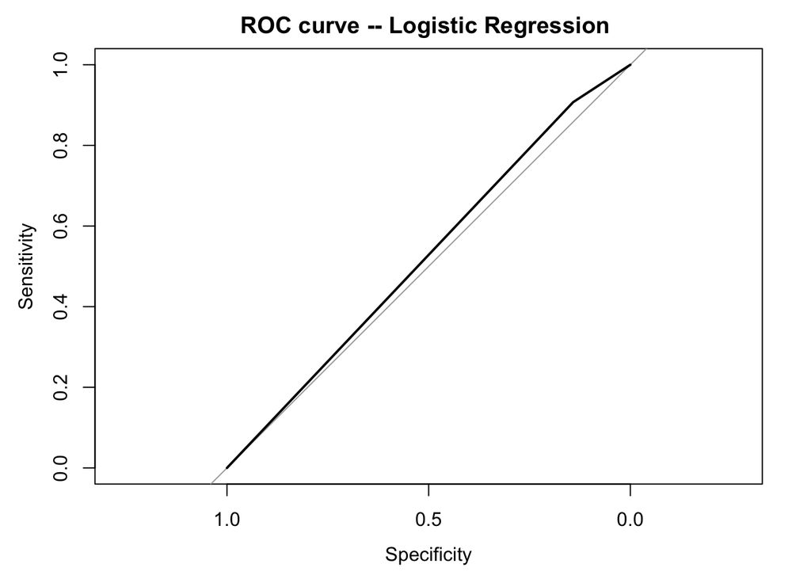

```r
plot(roc_score ,main ="ROC curve -- Logistic Regression ")
```

```r
#Another way to daw ROC plots is as follows using the verification package :
A<- c(0,0,0,1,1,1)
#y<- c(.9, .8, 0, 1, 4,.9)
B<- c(1,0,0,1,1,0)
examp<-data.frame(A,B)
names(examp)<-c("up","down")
#roc.plot(examp$up,examp$down)
```

## Reference

reference: “James, G., D. Witten, T. Hastie, and R. Tibshirani. 2013. “An Introduction to Statistical Learning.” https://link.springer.com/content/pdf/10.1007/978-1-0716-1418-1.pdf.”